# Objective

To predict the concrete strength using the data available in file concrete_data.xls. Apply feature engineering and model tuning to obtain 80% to 95% of R2score.

## Import Libraries

```python
import numpy as np
import pandas as pd
import seaborn as sns
import matplotlib.pyplot as plt
%matplotlib inline
from scipy import stats
import warnings
warnings.filterwarnings('ignore')
from IPython.core.interactiveshell import InteractiveShell
InteractiveShell.ast_node_interactivity='all'
```

## Import Dataset

```python
# Read the CSV file
df=pd.read_csv('concrete.csv')
```

## Univariate analysis

```python
df.info()       # Info about dataframe, columns, data types, Null values
```

```
<class 'pandas.core.frame.DataFrame'>
RangeIndex: 1030 entries, 0 to 1029
Data columns (total 9 columns):
 #   Column        Non-Null Count  Dtype
---  ------        --------------  -----
 0   cement        1030 non-null   float64
 1   slag          1030 non-null   float64
 2   ash           1030 non-null   float64
 3   water         1030 non-null   float64
 4   superplastic  1030 non-null   float64
 5   coarseagg     1030 non-null   float64
 6   fineagg       1030 non-null   float64
 7   age           1030 non-null   int64
 8   strength      1030 non-null   float64
dtypes: float64(8), int64(1)
memory usage: 72.5 KB
```

```python
print('Shape of the dataframe is:',df.shape)       # Shape of data frame
print('-----First five rows are-----')
df.head()                                          # First five rows
print('-----Last five rows are-----')
df.tail()                                          # Last five rows
print('-----Number of unique values-----')
df.nunique()                                       # Number of unique values in each column
print('-----Number of Nulls-----')
df.isnull().sum()                                  # Check Null values
df.describe().transpose()                          # Statistical summary
```

```
Shape of the dataframe is: (1030, 9)
-----First five rows are-----
```

|  | cement | slag | ash | water | superplastic | coarseagg | fineagg | age | strength |
| --- | --- | --- | --- | --- | --- | --- | --- | --- | --- |
| 0 | 141.3 | 212.0 | 0.0 | 203.5 | 0.0 | 971.8 | 748.5 | 28 | 29.89 |
| 1 | 168.9 | 42.2 | 124.3 | 158.3 | 10.8 | 1080.8 | 796.2 | 14 | 23.51 |
| 2 | 250.0 | 0.0 | 95.7 | 187.4 | 5.5 | 956.9 | 861.2 | 28 | 29.22 |
| 3 | 266.0 | 114.0 | 0.0 | 228.0 | 0.0 | 932.0 | 670.0 | 28 | 45.85 |
| 4 | 154.8 | 183.4 | 0.0 | 193.3 | 9.1 | 1047.4 | 696.7 | 28 | 18.29 |

```
-----Last five rows are-----
```

|  | cement | slag | ash | water | superplastic | coarseagg | fineagg | age | strength |
| --- | --- | --- | --- | --- | --- | --- | --- | --- | --- |
| 1025 | 135.0 | 0.0 | 166.0 | 180.0 | 10.0 | 961.0 | 805.0 | 28 | 13.29 |
| 1026 | 531.3 | 0.0 | 0.0 | 141.8 | 28.2 | 852.1 | 893.7 | 3 | 41.30 |
| 1027 | 276.4 | 116.0 | 90.3 | 179.6 | 8.9 | 870.1 | 768.3 | 28 | 44.28 |
| 1028 | 342.0 | 38.0 | 0.0 | 228.0 | 0.0 | 932.0 | 670.0 | 270 | 55.06 |
| 1029 | 540.0 | 0.0 | 0.0 | 173.0 | 0.0 | 1125.0 | 613.0 | 7 | 52.61 |

```
-----Number of unique values-----
```

```
cement          278
slag            185
ash             156
water           195
superplastic    111
coarseagg       284
fineagg         302
age              14
strength        845
dtype: int64
```

```
-----Number of Nulls-----
```

```
cement          0
slag            0
ash             0
water           0
superplastic    0
coarseagg       0
fineagg         0
age             0
strength        0
dtype: int64
```

|  | count | mean | std | min | 25% | 50% | 75% | max |
| --- | --- | --- | --- | --- | --- | --- | --- | --- |
| cement | 1030.0 | 281.167864 | 104.506364 | 102.00 | 192.375 | 272.900 | 350.000 | 540.0 |
| slag | 1030.0 | 73.895825 | 86.279342 | 0.00 | 0.000 | 22.000 | 142.950 | 359.4 |
| ash | 1030.0 | 54.188350 | 63.997004 | 0.00 | 0.000 | 0.000 | 118.300 | 200.1 |
| water | 1030.0 | 181.567282 | 21.354219 | 121.80 | 164.900 | 185.000 | 192.000 | 247.0 |
| superplastic | 1030.0 | 6.204660 | 5.973841 | 0.00 | 0.000 | 6.400 | 10.200 | 32.2 |
| coarseagg | 1030.0 | 972.918932 | 77.753954 | 801.00 | 932.000 | 968.000 | 1029.400 | 1145.0 |
| fineagg | 1030.0 | 773.580485 | 80.175980 | 594.00 | 730.950 | 779.500 | 824.000 | 992.6 |
| age | 1030.0 | 45.662136 | 63.169912 | 1.00 | 7.000 | 28.000 | 56.000 | 365.0 |
| strength | 1030.0 | 35.817961 | 16.705742 | 2.33 | 23.710 | 34.445 | 46.135 | 82.6 |

- The independent variables are --> cement, slag, ash, water, superplastic, coarseagg, fineagg, age
- All the columns are numeric
- The dependent variable is --> strength
- There are 1030 rows and 9 columns
- Age is integer rest all are float
- There are no null values

### Cement

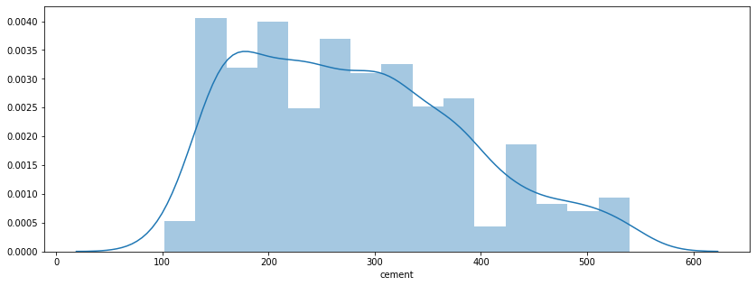

```python
plt.figure(figsize=(14,5))
sns.distplot(df['cement']);
```

```python
print('There are ',df['cement'].isnull().sum(),' nulls.')       # Check null
df['cement'].describe()                                         # Check mean, min, max, std, quartiles
print('Median is: ',df['cement'].median())                      # Median value
print('Range is: ', df['cement'].max() - df['cement'].min())    # Range
```

```
There are  0  nulls.
```

```
count    1030.000000
mean      281.167864
std       104.506364
min       102.000000
25%       192.375000
50%       272.900000
75%       350.000000
max       540.000000
Name: cement, dtype: float64
```

```
Median is:  272.9
Range is:  438.0
```

- Mean for cement is 281.167864
- Median (Q2) for cement is 272.9
- Not much difference between mean and median values
- Min value is 102
- Max value is 540
- Q1 is 192.375
- Q2 is 272.9
- Q3 is 350

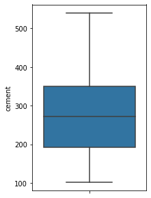

```python
plt.figure(figsize=(3,5))
sns.boxplot(x='cement',data=df, orient='v');
```

```python
# Q1 and Q3 values from above
outliers_lower=192.375-1.5*(350-192.375)
outliers_upper=350+1.5*(350-192.375)
print(outliers_lower)
print(outliers_upper)
# Number of outliers
print('Number of outliers lower:',df[df['cement']<outliers_lower]['cement'].count()) # Lower
print('Number of outliers upper:',df[df['cement']>outliers_upper]['cement'].count()) # Upper
```

```
-44.0625
586.4375
Number of outliers lower: 0
Number of outliers upper: 0
```

### Analysis for cement

- The minimum is 102 and maximum is 540 so the spread is across
- There is little variance between mean and median values and we do not see any null values
- There are no outliers

### Slag

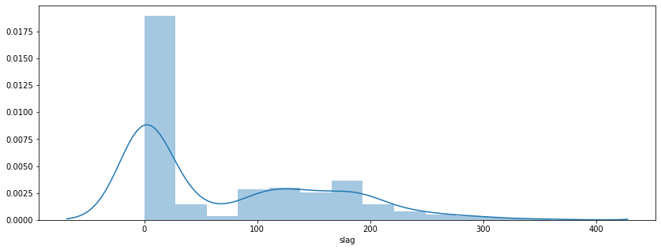

```python
plt.figure(figsize=(14,5))
sns.distplot(df['slag']);
```

```python
print('There are ',df['slag'].isnull().sum(),' nulls.')       # Check null
df['slag'].describe()                                         # Check mean, min, max, std, quartiles
print('Median is: ',df['slag'].median())                      # Median value
print('Range is: ', df['slag'].max() - df['slag'].min())      # Range
```

```
There are  0  nulls.
```

```
count    1030.000000
mean       73.895825
std        86.279342
min         0.000000
25%         0.000000
50%        22.000000
75%       142.950000
max       359.400000
Name: slag, dtype: float64
```

```
Median is:  22.0
Range is:  359.4
```

- Mean for slag is 73.895825
- Median (Q2) for slag is 22
- There is difference between mean and median values
- Min value is 0
- Max value is 359.4
- Q1 is 0
- Q2 is 22
- Q3 is 142.95

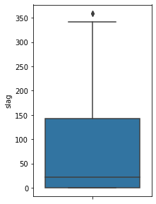

```python
plt.figure(figsize=(3,5))
sns.boxplot(x='slag',data=df, orient='v');
```

```python
# Q1 and Q3 values from above
outliers_lower=0-1.5*(142.95-0)
outliers_upper=142.95+1.5*(142.95-0)
print(outliers_lower)
print(outliers_upper)
# Number of outliers
print('Number of outliers lower:',df[df['slag']<outliers_lower]['slag'].count()) # Lower
print('Number of outliers upper:',df[df['slag']>outliers_upper]['slag'].count()) # Upper
```

```
-214.42499999999998
357.375
Number of outliers lower: 0
Number of outliers upper: 2
```

### Analysis for slag

- The minimum is 0 and maximum is 359.4
- There is variance between mean and median values and we do not see any null values
- The data for slag is right skewed as can be seen from distplot and boxplot above
- Though there are very small number of outliers

### Ash

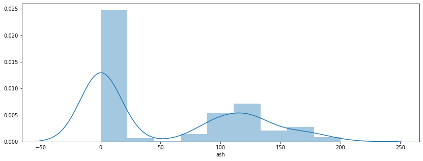

```python
plt.figure(figsize=(14,5))
sns.distplot(df['ash']);
```

```python
print('There are ',df['ash'].isnull().sum(),' nulls.')       # Check null
df['ash'].describe()                                         # Check mean, min, max, std, quartiles
print('Median is: ',df['ash'].median())                      # Median value
print('Range is: ', df['ash'].max() - df['ash'].min())       # Range
```

```
There are  0  nulls.
```

```
count    1030.000000
mean       54.188350
std        63.997004
min         0.000000
25%         0.000000
50%         0.000000
75%       118.300000
max       200.100000
Name: ash, dtype: float64
```

```
Median is:  0.0
Range is:  200.1
```

- Mean for ash is 54.188350
- Median (Q2) for slag is 0
- There is difference between mean and median values
- Min value is 0
- Max value is 200.1
- Q1 is 0
- Q2 is 0
- Q3 is 118.3

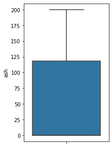

```python
plt.figure(figsize=(3,5))
sns.boxplot(x='ash',data=df, orient='v');
```

```python
# Q1 and Q3 values from above
outliers_lower=0-1.5*(118.3-0)
outliers_upper=118.3+1.5*(118.3-0)
print(outliers_lower)
print(outliers_upper)
# Number of outliers
print('Number of outliers lower:',df[df['ash']<outliers_lower]['ash'].count()) # Lower
print('Number of outliers upper:',df[df['ash']>outliers_upper]['ash'].count()) # Upper
```

```
-177.45
295.75
Number of outliers lower: 0
Number of outliers upper: 0
```

### Analysis for ash

- The minimum is 0 and maximum is 200.1
- There is variance between mean and median values and we do not see any null values
- There are no outliers

### Water

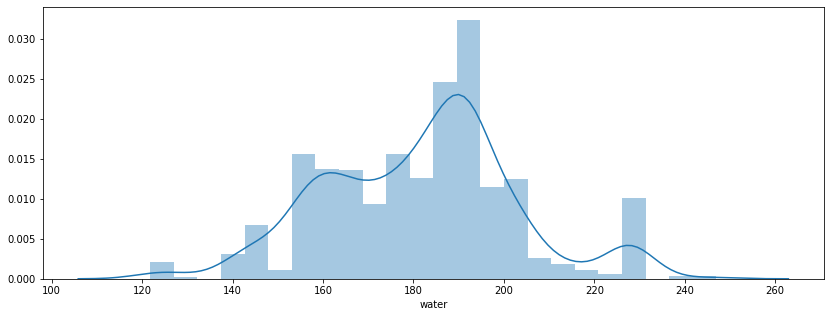

```python
plt.figure(figsize=(14,5))
sns.distplot(df['water']);
```

```python
print('There are ',df['water'].isnull().sum(),' nulls.')       # Check null
df['water'].describe()                                         # Check mean, min, max, std, quartiles
print('Median is: ',df['water'].median())                      # Median value
print('Range is: ', df['water'].max() - df['water'].min())     # Range
```

```
There are  0  nulls.
```

```
count    1030.000000
mean      181.567282
std        21.354219
min       121.800000
25%       164.900000
50%       185.000000
75%       192.000000
max       247.000000
Name: water, dtype: float64
```

```
Median is:  185.0
Range is:  125.2
```

- Mean for water is 181.567282
- Median (Q2) for water is 185
- There is minimal difference between mean and median values
- Min value is 121.8
- Max value is 247
- Q1 is 164.9
- Q2 is 185
- Q3 is 192

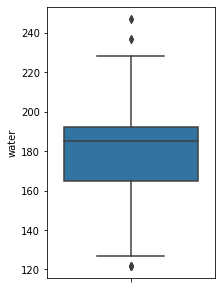

```python
plt.figure(figsize=(3,5))
sns.boxplot(x='water',data=df, orient='v');
```

```python
# Q1 and Q3 values from above
outliers_lower=164.9-1.5*(192-164.9)
outliers_upper=192+1.5*(192-164.9)
print(outliers_lower)
print(outliers_upper)
# Number of outliers
print('Number of outliers lower:',df[df['water']<outliers_lower]['water'].count()) # Lower
print('Number of outliers upper:',df[df['water']>outliers_upper]['water'].count()) # Upper
```

```
124.25000000000001
232.64999999999998
Number of outliers lower: 5
Number of outliers upper: 4
```

### Analysis for water

- The minimum is 121.8 and maximum is 247
- There is minimal variance between mean and median values and we do not see any null values
- There are small number of outliers

### Superplastic

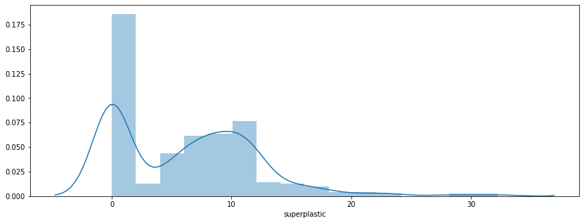

```python
plt.figure(figsize=(14,5))
sns.distplot(df['superplastic']);
```

```python
print('There are ',df['superplastic'].isnull().sum(),' nulls.')             # Check null
df['superplastic'].describe()                                               # Check mean, min, max, std, quartiles
print('Median is: ',df['superplastic'].median())                            # Median value
print('Range is: ', df['superplastic'].max() - df['superplastic'].min())    # Range
```

```
There are  0  nulls.
```

```
count    1030.000000
mean        6.204660
std         5.973841
min         0.000000
25%         0.000000
50%         6.400000
75%        10.200000
max        32.200000
Name: superplastic, dtype: float64
```

```
Median is:  6.4
Range is:  32.2
```

- Mean for superplastic is 6.204660
- Median (Q2) for superplastic is 6.4
- Mean and median values are more or less similar
- Min value is 0
- Max value is 32.2
- Q1 is 0
- Q2 is 6.4
- Q3 is 10.2

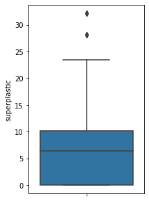

```python
plt.figure(figsize=(3,5))
sns.boxplot(x='superplastic',data=df, orient='v');
```

```python
# Q1 and Q3 values from above
outliers_lower=0-1.5*(10.2-0)
outliers_upper=10.2+1.5*(10.2-0)
print(outliers_lower)
print(outliers_upper)
# Number of outliers
print('Number of outliers lower:',df[df['superplastic']<outliers_lower]['superplastic'].count()) # Lower
print('Number of outliers upper:',df[df['superplastic']>outliers_upper]['superplastic'].count()) # Upper
```

```
-15.299999999999999
25.5
Number of outliers lower: 0
Number of outliers upper: 10
```

### Analysis for superplastic

- The minimum is 0 and maximum is 32.2
- Mean and median values are approximately same and we do not see any null values
- There are small number of outliers and data is slightly right skewed

### Coarseagg

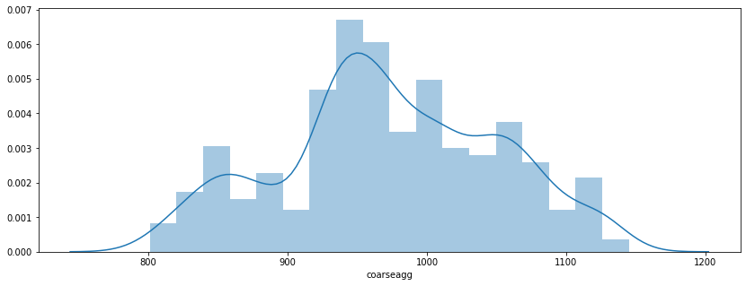

```python
plt.figure(figsize=(14,5))
sns.distplot(df['coarseagg']);
```

```python
print('There are ',df['coarseagg'].isnull().sum(),' nulls.')          # Check null
df['coarseagg'].describe()                                            # Check mean, min, max, std, quartiles
print('Median is: ',df['coarseagg'].median())                         # Median value
print('Range is: ', df['coarseagg'].max() - df['coarseagg'].min())    # Range
```

```
There are  0  nulls.
```

```
count    1030.000000
mean      972.918932
std        77.753954
min       801.000000
25%       932.000000
50%       968.000000
75%      1029.400000
max      1145.000000
Name: coarseagg, dtype: float64
```

```
Median is:  968.0
Range is:  344.0
```

- Mean for coarseagg is 972.918932
- Median (Q2) for coarseagg is 968
- There is slight variance in Mean and median values
- Min value is 801
- Max value is 1145
- Q1 is 932
- Q2 is 968
- Q3 is 1029.4

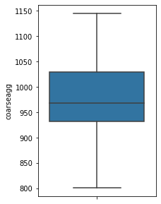

```python
plt.figure(figsize=(3,5))
sns.boxplot(x='coarseagg',data=df, orient='v');
```

```python
# Q1 and Q3 values from above
outliers_lower=932-1.5*(1029.4-932)
outliers_upper=1029.4+1.5*(1029.4-932)
print(outliers_lower)
print(outliers_upper)
# Number of outliers
print('Number of outliers lower:',df[df['coarseagg']<outliers_lower]['coarseagg'].count()) # Lower
print('Number of outliers upper:',df[df['coarseagg']>outliers_upper]['coarseagg'].count()) # Upper
```

```
785.8999999999999
1175.5000000000002
Number of outliers lower: 0
Number of outliers upper: 0
```

### Analysis for coarseagg

- The minimum is 801 and maximum is 1145
- Mean and median values are more less same and we do not see any null values
- There are no outliers

### Fineagg

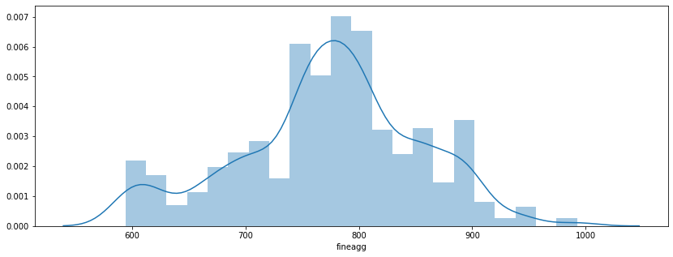

```python
plt.figure(figsize=(14,5))
sns.distplot(df['fineagg']);
```

```python
print('There are ',df['fineagg'].isnull().sum(),' nulls.')        # Check null
df['fineagg'].describe()                                          # Check mean, min, max, std, quartiles
print('Median is: ',df['fineagg'].median())                       # Median value
print('Range is: ', df['fineagg'].max() - df['fineagg'].min())    # Range
```

```
There are  0  nulls.
```

```
count    1030.000000
mean      773.580485
std        80.175980
min       594.000000
25%       730.950000
50%       779.500000
75%       824.000000
max       992.600000
Name: fineagg, dtype: float64
```

```
Median is:  779.5
Range is:  398.6
```

- Mean for fineagg is 773.580485
- Median (Q2) for fineagg is 779.5
- There is slight variance in Mean and median values
- Min value is 594
- Max value is 992.6
- Q1 is 730.95
- Q2 is 779.5
- Q3 is 824

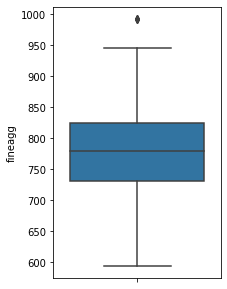

```python
plt.figure(figsize=(3,5))
sns.boxplot(x='fineagg',data=df, orient='v');
```

```python
# Q1 and Q3 values from above
outliers_lower=730.95-1.5*(824-730.95)
outliers_upper=824+1.5*(824-730.95)
print(outliers_lower)
print(outliers_upper)
# Number of outliers
print('Number of outliers lower:',df[df['fineagg']<outliers_lower]['fineagg'].count()) # Lower
print('Number of outliers upper:',df[df['fineagg']>outliers_upper]['fineagg'].count()) # Upper
```

```
591.3750000000001
963.5749999999999
Number of outliers lower: 0
Number of outliers upper: 5
```

### Analysis for fineagg

- The minimum is 594 and maximum is 992.6
- Mean and median values are more less same and we do not see any null values
- There are small number of outliers

### Age

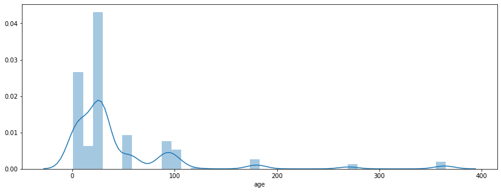

```python
plt.figure(figsize=(14,5))
sns.distplot(df['age']);
```

```python
print('There are ',df['age'].isnull().sum(),' nulls.')       # Check null
df['age'].describe()                                         # Check mean, min, max, std, quartiles
print('Median is: ',df['age'].median())                      # Median value
print('Range is: ', df['age'].max() - df['age'].min())       # Range
```

```
There are  0  nulls.
```

```
count    1030.000000
mean       45.662136
std        63.169912
min         1.000000
25%         7.000000
50%        28.000000
75%        56.000000
max       365.000000
Name: age, dtype: float64
```

```
Median is:  28.0
Range is:  364
```

- Mean for age is 45.662136
- Median (Q2) for age is 28
- There is variance in Mean and median values
- Min value is 1
- Max value is 365
- Q1 is 7
- Q2 is 28
- Q3 is 56

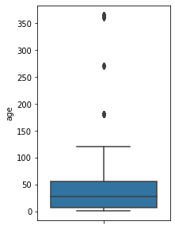

```python
plt.figure(figsize=(3,5))
sns.boxplot(x='age',data=df, orient='v');
```

```python
# Q1 and Q3 values from above
outliers_lower=7-1.5*(56-7)
outliers_upper=56+1.5*(56-7)
print(outliers_lower)
print(outliers_upper)
# Number of outliers
print('Number of outliers lower:',df[df['age']<outliers_lower]['age'].count()) # Lower
print('Number of outliers upper:',df[df['age']>outliers_upper]['age'].count()) # Upper
```

```
-66.5
129.5
Number of outliers lower: 0
Number of outliers upper: 59
```

### Analysis for age

- The minimum is 1 and maximum is 365
- There is variance in Mean and median values and we do not see any null values
- There are 59 outliers and data is right skewed

### Strength

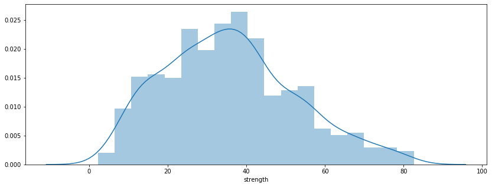

```python
plt.figure(figsize=(14,5))
sns.distplot(df['strength']);
```

```python
print('There are ',df['strength'].isnull().sum(),' nulls.')       # Check null
df['strength'].describe()                                         # Check mean, min, max, std, quartiles
print('Median is: ',df['strength'].median())                      # Median value
print('Range is: ', df['strength'].max() - df['strength'].min())  # Range
```

```
There are  0  nulls.
```

```
count    1030.000000
mean       35.817961
std        16.705742
min         2.330000
25%        23.710000
50%        34.445000
75%        46.135000
max        82.600000
Name: strength, dtype: float64
```

```
Median is:  34.445
Range is:  80.27
```

- Mean for strength is 35.817961
- Median (Q2) for strength is 34.445
- There is minimal variance in Mean and median values
- Min value is 2.33
- Max value is 82.6
- Q1 is 23.71
- Q2 is 34.445
- Q3 is 46.135

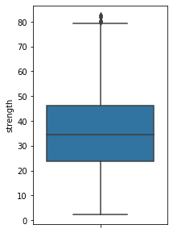

```python
plt.figure(figsize=(3,5))
sns.boxplot(x='strength',data=df, orient='v');
```

```python
# Q1 and Q3 values from above
outliers_lower=23.71-1.5*(46.135-23.71)
outliers_upper=46.135+1.5*(46.135-23.71)
print(outliers_lower)
print(outliers_upper)
# Number of outliers
print('Number of outliers lower:',df[df['strength']<outliers_lower]['strength'].count()) # Lower
print('Number of outliers upper:',df[df['strength']>outliers_upper]['strength'].count()) # Upper
```

```
-9.927499999999995
79.7725
Number of outliers lower: 0
Number of outliers upper: 4
```

### Analysis for strength

- The minimum is 2.33 and maximum is 82.6
- Mean and median values are more less same and we do not see any null values
- There are small number of outliers

#### We see above there are outliers, but the number of outliers is very small, hence we will leave them as is.

### Duplicates

Let's find duplicate rows in the data and in case they are exact match then we will delete them.

```python
df_orig=df
df_orig.shape
print('Duplicate Rows:')
print(df[df.duplicated()])
df=df.drop_duplicates()
df.shape
```

```
(1030, 9)
```

```
Duplicate Rows:
     cement   slag  ash  water  superplastic  coarseagg  fineagg  age  \
278   425.0  106.3  0.0  153.5          16.5      852.1    887.1    3
298   425.0  106.3  0.0  153.5          16.5      852.1    887.1    3
400   362.6  189.0  0.0  164.9          11.6      944.7    755.8    3
420   362.6  189.0  0.0  164.9          11.6      944.7    755.8    3
463   362.6  189.0  0.0  164.9          11.6      944.7    755.8   56
468   252.0    0.0  0.0  185.0           0.0     1111.0    784.0   28
482   425.0  106.3  0.0  153.5          16.5      852.1    887.1   91
493   362.6  189.0  0.0  164.9          11.6      944.7    755.8   91
517   425.0  106.3  0.0  153.5          16.5      852.1    887.1   56
525   362.6  189.0  0.0  164.9          11.6      944.7    755.8   28
527   425.0  106.3  0.0  153.5          16.5      852.1    887.1   91
576   362.6  189.0  0.0  164.9          11.6      944.7    755.8    7
577   425.0  106.3  0.0  153.5          16.5      852.1    887.1   28
```

[output cut: 39 more lines]

```
(1005, 9)
```

## Multivariate and bivariate analysis

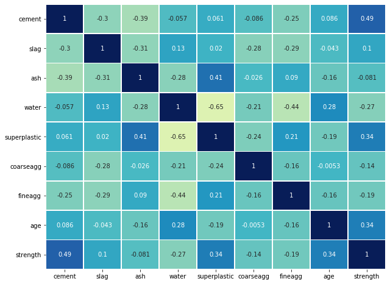

```python
plt.figure(figsize=(10,8))

sns.heatmap(df.corr(),
            annot=True,
            linewidths=.5,
            center=0,
            cbar=False,
            cmap="YlGnBu")

plt.show();
```

- water shows negative relationship (linear) with superplastic and fineagg
- there is a positive relationship between superplastic and ash
- there is a positive relationship between superplastic and fineagg
- there is a positive relation between age/cement/superplastic and strength
- there is a negative relation between water/fineagg/coarseagg and strength

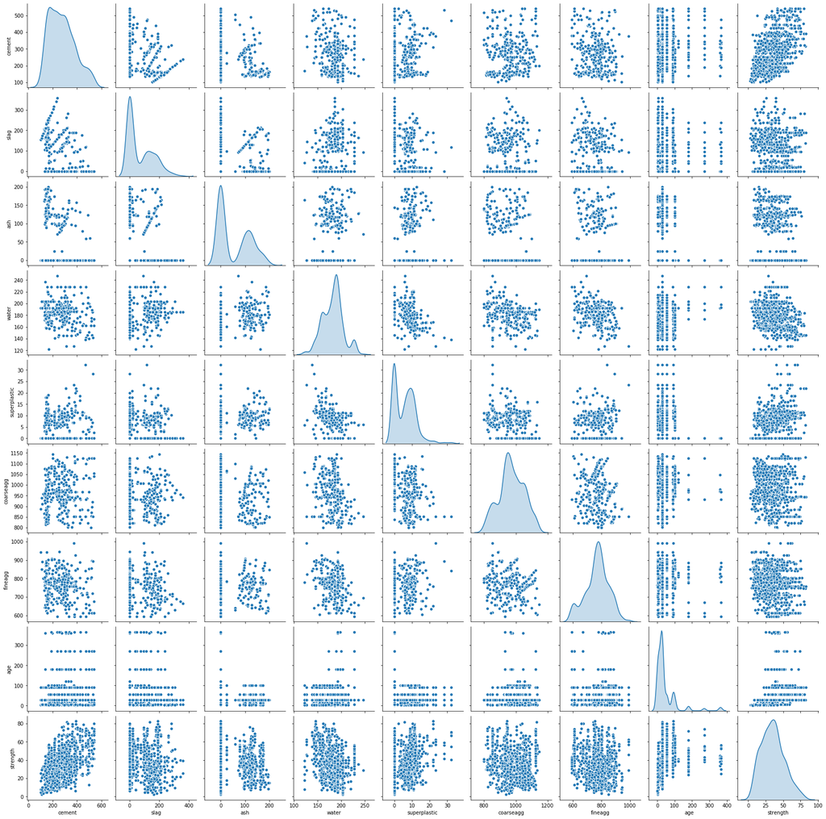

```python
sns.pairplot(df, diag_kind='kde');
```

- cement does not show any significant relation with slag, ash, water, superplatic, coarseagg, fineagg and age.
- slag does not show any significant relation with ash, water, superplatic, coarseagg, fineagg and age.
- ash does not show any significant relation with water, superplatic, coarseagg, fineagg and age.
- water shows negative relationship (linear) with superplastic and fineagg while does not show any significant relationship with others.
- superplastic shows negative linear relationship with water and does not show any significant relationship with others.
- coarseagg does not show any significant relation with any other columns.
- fineagg has negative linear relationship with water and it does not show any significant relation with any others.

### Strength vs Cement

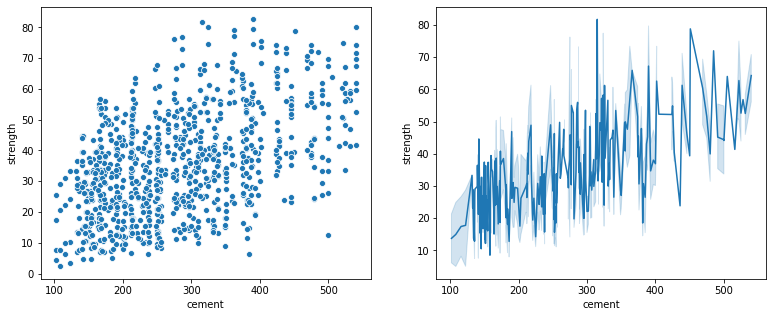

```python
# Strength vs Cement
fig, (ax1,ax2)=plt.subplots(1,2,figsize=(13,5))
sns.scatterplot(x='cement', y='strength', data=df, ax=ax1);
sns.lineplot(x='cement',y='strength', data=df, ax=ax2);
```

As can be seen above cement and strength are positively and linearly related. For a given vaulue of cement, we see multiple values for strength. Hence, cement will not be a good predictor.

### Strength vs Slag

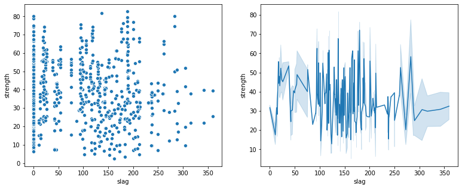

```python
# Strength vs Slag
fig, (ax1,ax2)=plt.subplots(1,2,figsize=(13,5))
sns.scatterplot(x='slag', y='strength', data=df, ax=ax1);
sns.lineplot(x='slag',y='strength', data=df, ax=ax2);
```

We do not see any trend, the values are scattered like a cloud.

### Strength vs Ash

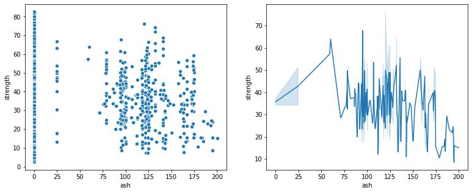

```python
# Strength vs Ash
fig, (ax1,ax2)=plt.subplots(1,2,figsize=(13,5))
sns.scatterplot(x='ash', y='strength', data=df, ax=ax1);
sns.lineplot(x='ash',y='strength', data=df, ax=ax2);
```

We do not see any trend and there is no linear relation.

### Strength vs Water

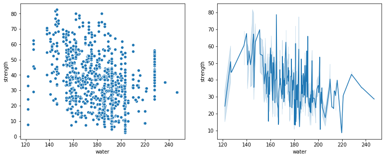

```python
# Strength vs Water
fig, (ax1,ax2)=plt.subplots(1,2,figsize=(13,5))
sns.scatterplot(x='water', y='strength', data=df, ax=ax1);
sns.lineplot(x='water',y='strength', data=df, ax=ax2);
```

We do not see any trend and there is no linear relation.

### Strength vs Superplastic

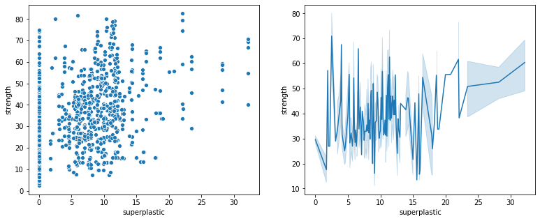

```python
# Strength vs Superplastic
fig, (ax1,ax2)=plt.subplots(1,2,figsize=(13,5))
sns.scatterplot(x='superplastic', y='strength', data=df, ax=ax1);
sns.lineplot(x='superplastic',y='strength', data=df, ax=ax2);
```

We do not see any trend and there is no linear relation.

### Strength vs Coarseagg

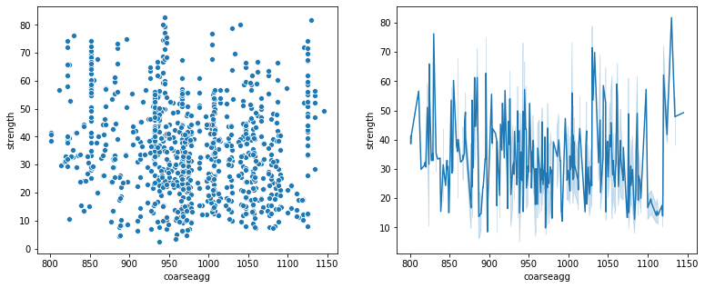

```python
# Strength vs Coarseagg
fig, (ax1,ax2)=plt.subplots(1,2,figsize=(13,5))
sns.scatterplot(x='coarseagg', y='strength', data=df, ax=ax1);
sns.lineplot(x='coarseagg',y='strength', data=df, ax=ax2);
```

We do not see any trend and there is no linear relation. For a given value of coarseagg there are multiple values of strength.

### Strength vs Fineagg

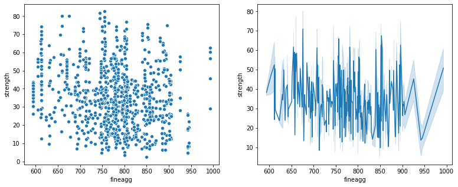

```python
# Strength vs Fineagg
fig, (ax1,ax2)=plt.subplots(1,2,figsize=(13,5))
sns.scatterplot(x='fineagg', y='strength', data=df, ax=ax1);
sns.lineplot(x='fineagg',y='strength', data=df, ax=ax2);
```

We do not see any trend and there is no linear relation. For a given value of fineagg there are multiple values of strength.

### Strength vs Age

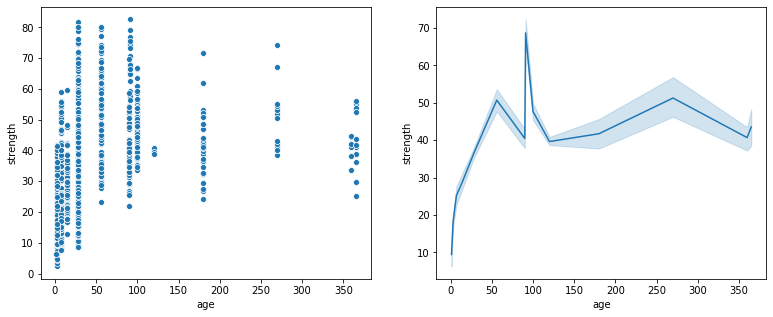

```python
# Strength vs Age
fig, (ax1,ax2)=plt.subplots(1,2,figsize=(13,5))
sns.scatterplot(x='age', y='strength', data=df, ax=ax1);
sns.lineplot(x='age',y='strength', data=df, ax=ax2);
```

For a given value of age there are multiple values of strength. Hence, it is not a good predictor for strength.

As we see that none of the independent attributes are good predictors of strength. There is a no linear relationship between them. Hence, linear model will not be a good option.

### Feature Engineering, Model Building

```python
from sklearn.preprocessing import StandardScaler
from scipy.stats import zscore
from sklearn.model_selection import train_test_split
from sklearn.tree import DecisionTreeRegressor
from sklearn.ensemble import RandomForestRegressor
from sklearn.ensemble import BaggingRegressor
from sklearn.ensemble import AdaBoostRegressor
from sklearn.ensemble import GradientBoostingRegressor
from sklearn.model_selection import RandomizedSearchCV
from sklearn.model_selection import cross_val_score
from sklearn.metrics import mean_squared_error, mean_absolute_error, r2_score
from sklearn.model_selection import KFold
```

```python
# Using z score for scaling as age is in different unit
std_scale = StandardScaler()
df = df.apply(zscore)
# df['age'] = std_scale.fit_transform(df[['age']])
```

```python
x=df.drop('strength',axis=1) # Independent variables
y=df['strength']             # Dependent variable
features = [col for col in df.columns if col != 'strength']
```

```python
x_train, x_test, y_train, y_test = train_test_split(x, y, test_size=0.30,random_state=1)   # Split data in 70:30 ratio
```

### Decision Tree

```python
dt = DecisionTreeRegressor()
dt.fit(x_train, y_train)
```

```
DecisionTreeRegressor(criterion='mse', max_depth=None, max_features=None,
                      max_leaf_nodes=None, min_impurity_decrease=0.0,
                      min_impurity_split=None, min_samples_leaf=1,
                      min_samples_split=2, min_weight_fraction_leaf=0.0,
                      presort=False, random_state=None, splitter='best')
```

```python
# Feature importance
pd.DataFrame(dt.feature_importances_,columns=['Imp'],index=x_train.columns)
```

|  | Imp |
| --- | --- |
| cement | 0.363587 |
| slag | 0.068998 |
| ash | 0.034680 |
| water | 0.119915 |
| superplastic | 0.040319 |
| coarseagg | 0.025959 |
| fineagg | 0.032207 |
| age | 0.314335 |

We see from above that cement, age and water are important features and the same was observed in the corelation metric as well.

```python
y_predict = dt.predict(x_test)             # Get predicted
```

```python
print("Train: %.2f" % dt.score(x_train, y_train))  # performance on train data
print("Test: %.2f" % dt.score(x_test, y_test))     # performance on test data
var_accuracy=metrics.r2_score(y_test, y_predict)
var_rmse=np.sqrt(mean_squared_error(y_test, y_predict))
print("Accuracy Score: %.2f" %var_accuracy)
print("RMSE: %.2f" %var_rmse)
```

```
Train: 1.00
Test: 0.77
Accuracy Score: 0.77
RMSE: 0.45
```

As we see this is an overfitting model with accuracy in train data and signifcantly lower score on test data

```python
#Store the accuracy results for each model in a dataframe for final comparison
resultsDf = pd.DataFrame({'Method':['Decision Tree'], 'Accuracy': var_accuracy, 'RMSE': var_rmse},index={'1'})
resultsDf = resultsDf[['Method', 'Accuracy', 'RMSE']]
resultsDf
```

|  | Method | Accuracy | RMSE |
| --- | --- | --- | --- |
| 1 | Decision Tree | 0.772225 | 0.446974 |

### K fold Cross Validation

```python
num_folds = 50
seed = 7
kfold = KFold(n_splits=num_folds, random_state=seed)
results = cross_val_score(dt,x, y, cv=kfold)
var_accuracy=np.mean(abs(results))
print('Average accuracy: ',var_accuracy)
print('Standard Deviation: ',results.std())
```

```
Average accuracy:  0.8510747533029616
Standard Deviation:  0.1056594918353185
```

```python
tempResultsDf = pd.DataFrame({'Method':['Decision Tree k fold'], 'Accuracy': [var_accuracy], 'RMSE': [var_rmse]},index={'2'})
resultsDf = pd.concat([resultsDf, tempResultsDf])
resultsDf = resultsDf[['Method', 'Accuracy', 'RMSE']]
resultsDf
```

|  | Method | Accuracy | RMSE |
| --- | --- | --- | --- |
| 1 | Decision Tree | 0.772225 | 0.446974 |
| 2 | Decision Tree k fold | 0.851075 | 0.446974 |

### Prune the Decision Tree

```python
dt_pruned = DecisionTreeRegressor(max_depth=6,random_state=1,min_samples_leaf=7)
dt_pruned.fit(x_train, y_train)
```

```
DecisionTreeRegressor(criterion='mse', max_depth=6, max_features=None,
                      max_leaf_nodes=None, min_impurity_decrease=0.0,
                      min_impurity_split=None, min_samples_leaf=7,
                      min_samples_split=2, min_weight_fraction_leaf=0.0,
                      presort=False, random_state=1, splitter='best')
```

```python
y_predict = dt_pruned.predict(x_test)             # Get predicted
```

```python
print("Train: %.2f" % dt.score(x_train, y_train))  # performance on train data
print("Test: %.2f" % dt.score(x_test, y_test))     # performance on test data
var_accuracy=metrics.r2_score(y_test, y_predict)
var_rmse=np.sqrt(mean_squared_error(y_test, y_predict))
print("Accuracy Score: %.2f" %var_accuracy)
print("RMSE: %.2f" %var_rmse)
```

```
Train: 1.00
Test: 0.77
Accuracy Score: 0.75
RMSE: 0.47
```

```python
tempResultsDf = pd.DataFrame({'Method':['Pruned Decision Tree'], 'Accuracy': [var_accuracy], 'RMSE': [var_rmse]},index={'3'})
resultsDf = pd.concat([resultsDf, tempResultsDf])
resultsDf = resultsDf[['Method', 'Accuracy', 'RMSE']]
resultsDf
```

|  | Method | Accuracy | RMSE |
| --- | --- | --- | --- |
| 1 | Decision Tree | 0.772225 | 0.446974 |
| 2 | Decision Tree k fold | 0.851075 | 0.446974 |
| 3 | Pruned Decision Tree | 0.750451 | 0.467851 |

```python
# Feature importance
pd.DataFrame(dt_pruned.feature_importances_,columns=['Imp'],index=x_train.columns)
```

|  | Imp |
| --- | --- |
| cement | 0.395247 |
| slag | 0.060407 |
| ash | 0.014514 |
| water | 0.124940 |
| superplastic | 0.032375 |
| coarseagg | 0.017837 |
| fineagg | 0.014775 |
| age | 0.339906 |

We see from above that cement, age and water are important features, as observed above.

```python
from sklearn.tree import export_graphviz
from sklearn.externals.six import StringIO
from IPython.display import Image
import graphviz
import pydotplus

df_new=df
xvar = df_new.drop('strength', axis=1)
feature_cols = xvar.columns
```

[output not shown]

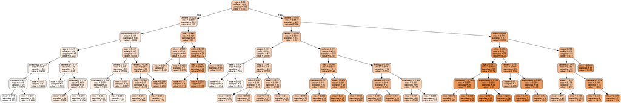

```python
dot_data = StringIO()
export_graphviz(dt_pruned, out_file=dot_data,
                filled=True, rounded=True,
                special_characters=True,feature_names = features,class_names=['0','1'])
graph = pydotplus.graph_from_dot_data(dot_data.getvalue())
graph.write_png('Pruned.png')
Image(graph.create_png())
```

### K fold Cross Validation

```python
num_folds = 50
seed = 7
kfold = KFold(n_splits=num_folds, random_state=seed)
results = cross_val_score(dt_pruned,x, y, cv=kfold)
var_accuracy=np.mean(abs(results))
print('Average accuracy: ',var_accuracy)
print('Standard Deviation: ',results.std())
```

```
Average accuracy:  0.7300139845601384
Standard Deviation:  0.11797695447442333
```

```python
tempResultsDf = pd.DataFrame({'Method':['Pruned Decision Tree k fold'], 'Accuracy': [var_accuracy], 'RMSE': [var_rmse]},index={'4'})
resultsDf = pd.concat([resultsDf, tempResultsDf])
resultsDf = resultsDf[['Method', 'Accuracy', 'RMSE']]
resultsDf
```

|  | Method | Accuracy | RMSE |
| --- | --- | --- | --- |
| 1 | Decision Tree | 0.772225 | 0.446974 |
| 2 | Decision Tree k fold | 0.851075 | 0.446974 |
| 3 | Pruned Decision Tree | 0.750451 | 0.467851 |
| 4 | Pruned Decision Tree k fold | 0.730014 | 0.467851 |

### Random Forest

```python
rf = RandomForestRegressor()
rf.fit(x_train, y_train)
```

```
RandomForestRegressor(bootstrap=True, criterion='mse', max_depth=None,
                      max_features='auto', max_leaf_nodes=None,
                      min_impurity_decrease=0.0, min_impurity_split=None,
                      min_samples_leaf=1, min_samples_split=2,
                      min_weight_fraction_leaf=0.0, n_estimators=10,
                      n_jobs=None, oob_score=False, random_state=None,
                      verbose=0, warm_start=False)
```

```python
y_predict = rf.predict(x_test)             # Get predicted
```

```python
print("Train: %.2f" % dt.score(x_train, y_train))  # performance on train data
print("Test: %.2f" % dt.score(x_test, y_test))     # performance on test data
var_accuracy=metrics.r2_score(y_test, y_predict)
var_rmse=np.sqrt(mean_squared_error(y_test, y_predict))
print("Accuracy Score: %.2f" %var_accuracy)
print("RMSE: %.2f" %var_rmse)
```

```
Train: 1.00
Test: 0.77
Accuracy Score: 0.88
RMSE: 0.32
```

```python
tempResultsDf = pd.DataFrame({'Method':['Random Forest'], 'Accuracy': [var_accuracy], 'RMSE': [var_rmse]},index={'5'})
resultsDf = pd.concat([resultsDf, tempResultsDf])
resultsDf = resultsDf[['Method', 'Accuracy', 'RMSE']]
resultsDf
```

|  | Method | Accuracy | RMSE |
| --- | --- | --- | --- |
| 1 | Decision Tree | 0.772225 | 0.446974 |
| 2 | Decision Tree k fold | 0.851075 | 0.446974 |
| 3 | Pruned Decision Tree | 0.750451 | 0.467851 |
| 4 | Pruned Decision Tree k fold | 0.730014 | 0.467851 |
| 5 | Random Forest | 0.883752 | 0.319316 |

### K Fold cross validation

```python
num_folds = 50
seed = 7
kfold = KFold(n_splits=num_folds, random_state=seed)
results = cross_val_score(rf,x, y, cv=kfold)
var_accuracy=np.mean(abs(results))
print('Average accuracy: ',var_accuracy)
print('Standard Deviation: ',results.std())
```

```
Average accuracy:  0.892429025978545
Standard Deviation:  0.06488606335744182
```

```python
tempResultsDf = pd.DataFrame({'Method':['Random Forest k fold'], 'Accuracy': [var_accuracy], 'RMSE': [var_rmse]},index={'6'})
resultsDf = pd.concat([resultsDf, tempResultsDf])
resultsDf = resultsDf[['Method', 'Accuracy', 'RMSE']]
resultsDf
```

|  | Method | Accuracy | RMSE |
| --- | --- | --- | --- |
| 1 | Decision Tree | 0.772225 | 0.446974 |
| 2 | Decision Tree k fold | 0.851075 | 0.446974 |
| 3 | Pruned Decision Tree | 0.750451 | 0.467851 |
| 4 | Pruned Decision Tree k fold | 0.730014 | 0.467851 |
| 5 | Random Forest | 0.883752 | 0.319316 |
| 6 | Random Forest k fold | 0.892429 | 0.319316 |

### Bagging

```python
bg = BaggingRegressor()
bg.fit(x_train, y_train)
```

```
BaggingRegressor(base_estimator=None, bootstrap=True, bootstrap_features=False,
                 max_features=1.0, max_samples=1.0, n_estimators=10,
                 n_jobs=None, oob_score=False, random_state=None, verbose=0,
                 warm_start=False)
```

```python
y_predict = bg.predict(x_test)             # Get predicted
```

```python
print("Train: %.2f" % dt.score(x_train, y_train))  # performance on train data
print("Test: %.2f" % dt.score(x_test, y_test))     # performance on test data
var_accuracy=metrics.r2_score(y_test, y_predict)
var_rmse=np.sqrt(mean_squared_error(y_test, y_predict))
print("Accuracy Score: %.2f" %var_accuracy)
print("RMSE: %.2f" %var_rmse)
```

```
Train: 1.00
Test: 0.77
Accuracy Score: 0.88
RMSE: 0.32
```

```python
tempResultsDf = pd.DataFrame({'Method':['Bagging'], 'Accuracy': [var_accuracy], 'RMSE': [var_rmse]},index={'7'})
resultsDf = pd.concat([resultsDf, tempResultsDf])
resultsDf = resultsDf[['Method', 'Accuracy', 'RMSE']]
resultsDf
```

|  | Method | Accuracy | RMSE |
| --- | --- | --- | --- |
| 1 | Decision Tree | 0.772225 | 0.446974 |
| 2 | Decision Tree k fold | 0.851075 | 0.446974 |
| 3 | Pruned Decision Tree | 0.750451 | 0.467851 |
| 4 | Pruned Decision Tree k fold | 0.730014 | 0.467851 |
| 5 | Random Forest | 0.883752 | 0.319316 |
| 6 | Random Forest k fold | 0.892429 | 0.319316 |
| 7 | Bagging | 0.883191 | 0.320086 |

### K Fold cross validation

```python
num_folds = 50
seed = 7
kfold = KFold(n_splits=num_folds, random_state=seed)
results = cross_val_score(bg,x, y, cv=kfold)
var_accuracy=np.mean(abs(results))
print('Average accuracy: ',var_accuracy)
print('Standard Deviation: ',results.std())
```

```
Average accuracy:  0.89525993615745
Standard Deviation:  0.0664224896743734
```

```python
tempResultsDf = pd.DataFrame({'Method':['Bagging k fold'], 'Accuracy': [var_accuracy], 'RMSE': [var_rmse]},index={'8'})
resultsDf = pd.concat([resultsDf, tempResultsDf])
resultsDf = resultsDf[['Method', 'Accuracy', 'RMSE']]
resultsDf
```

|  | Method | Accuracy | RMSE |
| --- | --- | --- | --- |
| 1 | Decision Tree | 0.772225 | 0.446974 |
| 2 | Decision Tree k fold | 0.851075 | 0.446974 |
| 3 | Pruned Decision Tree | 0.750451 | 0.467851 |
| 4 | Pruned Decision Tree k fold | 0.730014 | 0.467851 |
| 5 | Random Forest | 0.883752 | 0.319316 |
| 6 | Random Forest k fold | 0.892429 | 0.319316 |
| 7 | Bagging | 0.883191 | 0.320086 |
| 8 | Bagging k fold | 0.895260 | 0.320086 |

### Adaboost

```python
ab = AdaBoostRegressor()
ab.fit(x_train, y_train)
```

```
AdaBoostRegressor(base_estimator=None, learning_rate=1.0, loss='linear',
                  n_estimators=50, random_state=None)
```

```python
y_predict = ab.predict(x_test)             # Get predicted
```

```python
print("Train: %.2f" % dt.score(x_train, y_train))  # performance on train data
print("Test: %.2f" % dt.score(x_test, y_test))     # performance on test data
var_accuracy=metrics.r2_score(y_test, y_predict)
var_rmse=np.sqrt(mean_squared_error(y_test, y_predict))
print("Accuracy Score: %.2f" %var_accuracy)
print("RMSE: %.2f" %var_rmse)
```

```
Train: 1.00
Test: 0.77
Accuracy Score: 0.76
RMSE: 0.46
```

```python
tempResultsDf = pd.DataFrame({'Method':['Adaboost'], 'Accuracy': [var_accuracy], 'RMSE': [var_rmse]},index={'9'})
resultsDf = pd.concat([resultsDf, tempResultsDf])
resultsDf = resultsDf[['Method', 'Accuracy', 'RMSE']]
resultsDf
```

|  | Method | Accuracy | RMSE |
| --- | --- | --- | --- |
| 1 | Decision Tree | 0.772225 | 0.446974 |
| 2 | Decision Tree k fold | 0.851075 | 0.446974 |
| 3 | Pruned Decision Tree | 0.750451 | 0.467851 |
| 4 | Pruned Decision Tree k fold | 0.730014 | 0.467851 |
| 5 | Random Forest | 0.883752 | 0.319316 |
| 6 | Random Forest k fold | 0.892429 | 0.319316 |
| 7 | Bagging | 0.883191 | 0.320086 |
| 8 | Bagging k fold | 0.895260 | 0.320086 |
| 9 | Adaboost | 0.759137 | 0.459636 |

### K Fold cross validation

```python
num_folds = 50
seed = 7
kfold = KFold(n_splits=num_folds, random_state=seed)
results = cross_val_score(ab,x, y, cv=kfold)
var_accuracy=np.mean(abs(results))
print('Average accuracy: ',var_accuracy)
print('Standard Deviation: ',results.std())
```

```
Average accuracy:  0.7581064244859413
Standard Deviation:  0.07865048939547582
```

```python
tempResultsDf = pd.DataFrame({'Method':['Adaboost k fold'], 'Accuracy': [var_accuracy], 'RMSE': [var_rmse]},index={'10'})
resultsDf = pd.concat([resultsDf, tempResultsDf])
resultsDf = resultsDf[['Method', 'Accuracy', 'RMSE']]
resultsDf
```

|  | Method | Accuracy | RMSE |
| --- | --- | --- | --- |
| 1 | Decision Tree | 0.772225 | 0.446974 |
| 2 | Decision Tree k fold | 0.851075 | 0.446974 |
| 3 | Pruned Decision Tree | 0.750451 | 0.467851 |
| 4 | Pruned Decision Tree k fold | 0.730014 | 0.467851 |
| 5 | Random Forest | 0.883752 | 0.319316 |
| 6 | Random Forest k fold | 0.892429 | 0.319316 |
| 7 | Bagging | 0.883191 | 0.320086 |
| 8 | Bagging k fold | 0.895260 | 0.320086 |
| 9 | Adaboost | 0.759137 | 0.459636 |
| 10 | Adaboost k fold | 0.758106 | 0.459636 |

```python
gb = AdaBoostRegressor()
gb.fit(x_train, y_train)
```

```
AdaBoostRegressor(base_estimator=None, learning_rate=1.0, loss='linear',
                  n_estimators=50, random_state=None)
```

```python
y_predict = gb.predict(x_test)             # Get predicted
```

```python
print("Train: %.2f" % dt.score(x_train, y_train))  # performance on train data
print("Test: %.2f" % dt.score(x_test, y_test))     # performance on test data
var_accuracy=metrics.r2_score(y_test, y_predict)
var_rmse=np.sqrt(mean_squared_error(y_test, y_predict))
print("Accuracy Score: %.2f" %var_accuracy)
print("RMSE: %.2f" %var_rmse)
```

```
Train: 1.00
Test: 0.77
Accuracy Score: 0.76
RMSE: 0.46
```

```python
tempResultsDf = pd.DataFrame({'Method':['Gradient Boost'], 'Accuracy': [var_accuracy], 'RMSE': [var_rmse]},index={'11'})
resultsDf = pd.concat([resultsDf, tempResultsDf])
resultsDf = resultsDf[['Method', 'Accuracy', 'RMSE']]
resultsDf
```

|  | Method | Accuracy | RMSE |
| --- | --- | --- | --- |
| 1 | Decision Tree | 0.772225 | 0.446974 |
| 2 | Decision Tree k fold | 0.851075 | 0.446974 |
| 3 | Pruned Decision Tree | 0.750451 | 0.467851 |
| 4 | Pruned Decision Tree k fold | 0.730014 | 0.467851 |
| 5 | Random Forest | 0.883752 | 0.319316 |
| 6 | Random Forest k fold | 0.892429 | 0.319316 |
| 7 | Bagging | 0.883191 | 0.320086 |
| 8 | Bagging k fold | 0.895260 | 0.320086 |
| 9 | Adaboost | 0.759137 | 0.459636 |
| 10 | Adaboost k fold | 0.758106 | 0.459636 |
| 11 | Gradient Boost | 0.760813 | 0.458035 |

### K Fold cross validation

```python
num_folds = 50
seed = 7
kfold = KFold(n_splits=num_folds, random_state=seed)
results = cross_val_score(gb,x, y, cv=kfold)
var_accuracy=np.mean(abs(results))
print('Average accuracy: ',var_accuracy)
print('Standard Deviation: ',results.std())
```

```
Average accuracy:  0.7505789436202237
Standard Deviation:  0.08453348700292194
```

```python
tempResultsDf = pd.DataFrame({'Method':['Gradient Boost k fold'], 'Accuracy': [var_accuracy], 'RMSE': [var_rmse]},index={'12'})
resultsDf = pd.concat([resultsDf, tempResultsDf])
resultsDf = resultsDf[['Method', 'Accuracy', 'RMSE']]
resultsDf
```

|  | Method | Accuracy | RMSE |
| --- | --- | --- | --- |
| 1 | Decision Tree | 0.772225 | 0.446974 |
| 2 | Decision Tree k fold | 0.851075 | 0.446974 |
| 3 | Pruned Decision Tree | 0.750451 | 0.467851 |
| 4 | Pruned Decision Tree k fold | 0.730014 | 0.467851 |
| 5 | Random Forest | 0.883752 | 0.319316 |
| 6 | Random Forest k fold | 0.892429 | 0.319316 |
| 7 | Bagging | 0.883191 | 0.320086 |
| 8 | Bagging k fold | 0.895260 | 0.320086 |
| 9 | Adaboost | 0.759137 | 0.459636 |
| 10 | Adaboost k fold | 0.758106 | 0.459636 |
| 11 | Gradient Boost | 0.760813 | 0.458035 |
| 12 | Gradient Boost k fold | 0.750579 | 0.458035 |

From above we see that Random Forest, Random Forest K-fold, Bagging, Bagging K-fold and Decision Tree K-fold have better results.

### Perform Random Search

#### Perform Randomized search on Random Forest

```python
n_estimators = [int(x) for x in np.linspace(start = 100, stop = 1000, num = 10)]
# Number of features to consider at every split
max_features = ['auto', 'sqrt']
# Maximum number of levels in tree
max_depth = [int(x) for x in np.linspace(10, 110, num = 11)]
max_depth.append(None)
# Minimum number of samples required to split a node
min_samples_split = [2, 5, 10]
# Minimum number of samples required at each leaf node
min_samples_leaf = [1, 2, 4, 8]
# Method of selecting samples for training each tree
bootstrap = [True, False]# Create the random grid
random_grid = {'n_estimators': n_estimators,
               'max_features': max_features,
               'max_depth': max_depth,
               'min_samples_split': min_samples_split,
               'min_samples_leaf': min_samples_leaf,
               'bootstrap': bootstrap}
print(random_grid)
```

```
{'n_estimators': [100, 200, 300, 400, 500, 600, 700, 800, 900, 1000], 'max_features': ['auto', 'sqrt'], 'max_depth': [10, 20, 30, 40, 50, 60, 70, 80, 90, 100, 110, None], 'min_samples_split': [2, 5, 10], 'min_samples_leaf': [1, 2, 4, 8], 'bootstrap': [True, False]}
```

```python
rf = RandomForestRegressor()
rf_random = RandomizedSearchCV(estimator = rf, param_distributions = random_grid, n_iter = 100, cv = 5, verbose=2, random_state=1, n_jobs = -1)# Fit the random search model
rf_random.fit(x_train, y_train)
```

```
Fitting 5 folds for each of 100 candidates, totalling 500 fits
```

```
[Parallel(n_jobs=-1)]: Using backend LokyBackend with 4 concurrent workers.
[Parallel(n_jobs=-1)]: Done  33 tasks      | elapsed:   43.4s
[Parallel(n_jobs=-1)]: Done 154 tasks      | elapsed:  1.3min
[Parallel(n_jobs=-1)]: Done 357 tasks      | elapsed:  2.0min
[Parallel(n_jobs=-1)]: Done 500 out of 500 | elapsed:  2.6min finished
```

```
RandomizedSearchCV(cv=5, error_score='raise-deprecating',
                   estimator=RandomForestRegressor(bootstrap=True,
                                                   criterion='mse',
                                                   max_depth=None,
                                                   max_features='auto',
                                                   max_leaf_nodes=None,
                                                   min_impurity_decrease=0.0,
                                                   min_impurity_split=None,
                                                   min_samples_leaf=1,
                                                   min_samples_split=2,
                                                   min_weight_fraction_leaf=0.0,
                                                   n_estimators='warn',
                                                   n_jobs=None, oob_score=False,
                                                   random_sta...
                   iid='warn', n_iter=100, n_jobs=-1,
                   param_distributions={'bootstrap': [True, False],
                                        'max_depth': [10, 20, 30, 40, 50, 60,
                                                      70, 80, 90, 100, 110,
                                                      None],
                                        'max_features': ['auto', 'sqrt'],
                                        'min_samples_leaf': [1, 2, 4, 8],
                                        'min_samples_split': [2, 5, 10],
                                        'n_estimators': [100, 200, 300, 400,
                                                         500, 600, 700, 800,
                                                         900, 1000]},
                   pre_dispatch='2*n_jobs', random_state=1, refit=True,
                   return_train_score=False, scoring=None, verbose=2)
```

```python
rf_random.best_params_
```

```
{'n_estimators': 700,
 'min_samples_split': 2,
 'min_samples_leaf': 1,
 'max_features': 'auto',
 'max_depth': 110,
 'bootstrap': True}
```

```python
y_predict  = rf_random.predict(x_test)
```

```python
print("Train: %.2f" % dt.score(x_train, y_train))  # performance on train data
print("Test: %.2f" % dt.score(x_test, y_test))     # performance on test data
var_accuracy=metrics.r2_score(y_test, y_predict)
var_rmse=np.sqrt(mean_squared_error(y_test, y_predict))
print("Accuracy Score: %.2f" %var_accuracy)
print("RMSE: %.2f" %var_rmse)
```

```
Train: 1.00
Test: 0.77
Accuracy Score: 0.90
RMSE: 0.30
```

```python
tempResultsDf = pd.DataFrame({'Method':['Random Forest Final'], 'Accuracy': [var_accuracy], 'RMSE': [var_rmse]},index={'13'})
resultsDf = pd.concat([resultsDf, tempResultsDf])
resultsDf = resultsDf[['Method', 'Accuracy', 'RMSE']]
resultsDf
```

|  | Method | Accuracy | RMSE |
| --- | --- | --- | --- |
| 1 | Decision Tree | 0.772225 | 0.446974 |
| 2 | Decision Tree k fold | 0.851075 | 0.446974 |
| 3 | Pruned Decision Tree | 0.750451 | 0.467851 |
| 4 | Pruned Decision Tree k fold | 0.730014 | 0.467851 |
| 5 | Random Forest | 0.883752 | 0.319316 |
| 6 | Random Forest k fold | 0.892429 | 0.319316 |
| 7 | Bagging | 0.883191 | 0.320086 |
| 8 | Bagging k fold | 0.895260 | 0.320086 |
| 9 | Adaboost | 0.759137 | 0.459636 |
| 10 | Adaboost k fold | 0.758106 | 0.459636 |
| 11 | Gradient Boost | 0.760813 | 0.458035 |
| 12 | Gradient Boost k fold | 0.750579 | 0.458035 |
| 13 | Random Forest Final | 0.896889 | 0.300734 |

### K Fold cross validation

```python
results = cross_val_score(rf_random,x, y, cv=5)
var_accuracy=np.mean(abs(results))
print('Average accuracy: ',var_accuracy)
print('Standard Deviation: ',results.std())
```

```
Fitting 5 folds for each of 100 candidates, totalling 500 fits
```

```
[Parallel(n_jobs=-1)]: Using backend LokyBackend with 4 concurrent workers.
[Parallel(n_jobs=-1)]: Done  33 tasks      | elapsed:   11.3s
[Parallel(n_jobs=-1)]: Done 154 tasks      | elapsed:   46.9s
[Parallel(n_jobs=-1)]: Done 357 tasks      | elapsed:  1.6min
[Parallel(n_jobs=-1)]: Done 500 out of 500 | elapsed:  2.2min finished
```

```
Fitting 5 folds for each of 100 candidates, totalling 500 fits
```

```
[Parallel(n_jobs=-1)]: Using backend LokyBackend with 4 concurrent workers.
[Parallel(n_jobs=-1)]: Done  33 tasks      | elapsed:   11.2s
[Parallel(n_jobs=-1)]: Done 154 tasks      | elapsed:   46.4s
[Parallel(n_jobs=-1)]: Done 357 tasks      | elapsed:  1.6min
[Parallel(n_jobs=-1)]: Done 500 out of 500 | elapsed:  2.2min finished
```

```
Fitting 5 folds for each of 100 candidates, totalling 500 fits
```

```
[Parallel(n_jobs=-1)]: Using backend LokyBackend with 4 concurrent workers.
[Parallel(n_jobs=-1)]: Done  33 tasks      | elapsed:   11.3s
[Parallel(n_jobs=-1)]: Done 154 tasks      | elapsed:   46.5s
[Parallel(n_jobs=-1)]: Done 357 tasks      | elapsed:  1.6min
[Parallel(n_jobs=-1)]: Done 500 out of 500 | elapsed:  2.2min finished
```

```
Fitting 5 folds for each of 100 candidates, totalling 500 fits
```

```
[Parallel(n_jobs=-1)]: Using backend LokyBackend with 4 concurrent workers.
[Parallel(n_jobs=-1)]: Done  33 tasks      | elapsed:   11.4s
[Parallel(n_jobs=-1)]: Done 154 tasks      | elapsed:   46.7s
[Parallel(n_jobs=-1)]: Done 357 tasks      | elapsed:  1.6min
[Parallel(n_jobs=-1)]: Done 500 out of 500 | elapsed:  2.2min finished
```

```
Fitting 5 folds for each of 100 candidates, totalling 500 fits
```

```
[Parallel(n_jobs=-1)]: Using backend LokyBackend with 4 concurrent workers.
[Parallel(n_jobs=-1)]: Done  33 tasks      | elapsed:   11.3s
[Parallel(n_jobs=-1)]: Done 154 tasks      | elapsed:   50.6s
[Parallel(n_jobs=-1)]: Done 357 tasks      | elapsed:  1.6min
[Parallel(n_jobs=-1)]: Done 500 out of 500 | elapsed:  2.2min finished
```

```
Average accuracy:  0.8992980171816191
Standard Deviation:  0.025197056651555746
```

```python
tempResultsDf = pd.DataFrame({'Method':['Random Forest Final k fold'], 'Accuracy': [var_accuracy], 'RMSE': [var_rmse]},index={'14'})
resultsDf = pd.concat([resultsDf, tempResultsDf])
resultsDf = resultsDf[['Method', 'Accuracy', 'RMSE']]
resultsDf
```

|  | Method | Accuracy | RMSE |
| --- | --- | --- | --- |
| 1 | Decision Tree | 0.772225 | 0.446974 |
| 2 | Decision Tree k fold | 0.851075 | 0.446974 |
| 3 | Pruned Decision Tree | 0.750451 | 0.467851 |
| 4 | Pruned Decision Tree k fold | 0.730014 | 0.467851 |
| 5 | Random Forest | 0.883752 | 0.319316 |
| 6 | Random Forest k fold | 0.892429 | 0.319316 |
| 7 | Bagging | 0.883191 | 0.320086 |
| 8 | Bagging k fold | 0.895260 | 0.320086 |
| 9 | Adaboost | 0.759137 | 0.459636 |
| 10 | Adaboost k fold | 0.758106 | 0.459636 |
| 11 | Gradient Boost | 0.760813 | 0.458035 |
| 12 | Gradient Boost k fold | 0.750579 | 0.458035 |
| 13 | Random Forest Final | 0.896889 | 0.300734 |
| 14 | Random Forest Final k fold | 0.899298 | 0.300734 |

#### Perform Randomized search for Bagging

```python
n_estimators = [int(x) for x in np.linspace(start = 100, stop = 1000, num = 10)]
bootstrap = [True, False]
random_grid = {'n_estimators': n_estimators,
               'bootstrap': bootstrap}
print(random_grid)
```

```
{'n_estimators': [100, 200, 300, 400, 500, 600, 700, 800, 900, 1000], 'bootstrap': [True, False]}
```

```python
bgcl = BaggingRegressor()
bgcl_random = RandomizedSearchCV(estimator = bgcl, param_distributions = random_grid, n_iter = 100, cv = 5, verbose=2, random_state=1, n_jobs = -1)# Fit the random search model
bgcl_random.fit(x_train, y_train)
```

```
Fitting 5 folds for each of 20 candidates, totalling 100 fits
```

```
[Parallel(n_jobs=-1)]: Using backend LokyBackend with 4 concurrent workers.
[Parallel(n_jobs=-1)]: Done  33 tasks      | elapsed:   10.0s
[Parallel(n_jobs=-1)]: Done 100 out of 100 | elapsed:   48.3s finished
```

```
RandomizedSearchCV(cv=5, error_score='raise-deprecating',
                   estimator=BaggingRegressor(base_estimator=None,
                                              bootstrap=True,
                                              bootstrap_features=False,
                                              max_features=1.0, max_samples=1.0,
                                              n_estimators=10, n_jobs=None,
                                              oob_score=False,
                                              random_state=None, verbose=0,
                                              warm_start=False),
                   iid='warn', n_iter=100, n_jobs=-1,
                   param_distributions={'bootstrap': [True, False],
                                        'n_estimators': [100, 200, 300, 400,
                                                         500, 600, 700, 800,
                                                         900, 1000]},
                   pre_dispatch='2*n_jobs', random_state=1, refit=True,
                   return_train_score=False, scoring=None, verbose=2)
```

```python
bgcl_random.best_params_
```

```
{'n_estimators': 900, 'bootstrap': True}
```

```python
y_predict  = bgcl_random.predict(x_test)
```

```python
print("Train: %.2f" % dt.score(x_train, y_train))  # performance on train data
print("Test: %.2f" % dt.score(x_test, y_test))     # performance on test data
var_accuracy=metrics.r2_score(y_test, y_predict)
var_rmse=np.sqrt(mean_squared_error(y_test, y_predict))
print("Accuracy Score: %.2f" %var_accuracy)
print("RMSE: %.2f" %var_rmse)
```

```
Train: 1.00
Test: 0.77
Accuracy Score: 0.90
RMSE: 0.30
```

```python
tempResultsDf = pd.DataFrame({'Method':['Bagging Final'], 'Accuracy': [var_accuracy], 'RMSE': [var_rmse]},index={'15'})
resultsDf = pd.concat([resultsDf, tempResultsDf])
resultsDf = resultsDf[['Method', 'Accuracy', 'RMSE']]
resultsDf
```

|  | Method | Accuracy | RMSE |
| --- | --- | --- | --- |
| 1 | Decision Tree | 0.772225 | 0.446974 |
| 2 | Decision Tree k fold | 0.851075 | 0.446974 |
| 3 | Pruned Decision Tree | 0.750451 | 0.467851 |
| 4 | Pruned Decision Tree k fold | 0.730014 | 0.467851 |
| 5 | Random Forest | 0.883752 | 0.319316 |
| 6 | Random Forest k fold | 0.892429 | 0.319316 |
| 7 | Bagging | 0.883191 | 0.320086 |
| 8 | Bagging k fold | 0.895260 | 0.320086 |
| 9 | Adaboost | 0.759137 | 0.459636 |
| 10 | Adaboost k fold | 0.758106 | 0.459636 |
| 11 | Gradient Boost | 0.760813 | 0.458035 |
| 12 | Gradient Boost k fold | 0.750579 | 0.458035 |
| 13 | Random Forest Final | 0.896889 | 0.300734 |
| 14 | Random Forest Final k fold | 0.899298 | 0.300734 |
| 15 | Bagging Final | 0.895690 | 0.302477 |

### K Fold Cross Validation

```python
results = cross_val_score(bgcl_random,x, y, cv=5)
var_accuracy=np.mean(abs(results))
print('Average accuracy: ',var_accuracy)
print('Standard Deviation: ',results.std())
```

```
Fitting 5 folds for each of 20 candidates, totalling 100 fits
```

```
[Parallel(n_jobs=-1)]: Using backend LokyBackend with 4 concurrent workers.
[Parallel(n_jobs=-1)]: Done  33 tasks      | elapsed:   10.8s
[Parallel(n_jobs=-1)]: Done 100 out of 100 | elapsed:   53.0s finished
```

```
Fitting 5 folds for each of 20 candidates, totalling 100 fits
```

```
[Parallel(n_jobs=-1)]: Using backend LokyBackend with 4 concurrent workers.
[Parallel(n_jobs=-1)]: Done  33 tasks      | elapsed:   10.8s
[Parallel(n_jobs=-1)]: Done 100 out of 100 | elapsed:   52.9s finished
```

```
Fitting 5 folds for each of 20 candidates, totalling 100 fits
```

```
[Parallel(n_jobs=-1)]: Using backend LokyBackend with 4 concurrent workers.
[Parallel(n_jobs=-1)]: Done  33 tasks      | elapsed:   10.7s
[Parallel(n_jobs=-1)]: Done 100 out of 100 | elapsed:   52.8s finished
```

```
Fitting 5 folds for each of 20 candidates, totalling 100 fits
```

```
[Parallel(n_jobs=-1)]: Using backend LokyBackend with 4 concurrent workers.
[Parallel(n_jobs=-1)]: Done  33 tasks      | elapsed:   10.7s
[Parallel(n_jobs=-1)]: Done 100 out of 100 | elapsed:   52.6s finished
```

```
Fitting 5 folds for each of 20 candidates, totalling 100 fits
```

```
[Parallel(n_jobs=-1)]: Using backend LokyBackend with 4 concurrent workers.
[Parallel(n_jobs=-1)]: Done  33 tasks      | elapsed:   10.9s
[Parallel(n_jobs=-1)]: Done 100 out of 100 | elapsed:   53.4s finished
```

```
Average accuracy:  0.9024428283404868
Standard Deviation:  0.02397831543764667
```

```python
tempResultsDf = pd.DataFrame({'Method':['Bagging Final k fold'], 'Accuracy': [var_accuracy], 'RMSE': [var_rmse]},index={'16'})
resultsDf = pd.concat([resultsDf, tempResultsDf])
resultsDf = resultsDf[['Method', 'Accuracy', 'RMSE']]
resultsDf
```

|  | Method | Accuracy | RMSE |
| --- | --- | --- | --- |
| 1 | Decision Tree | 0.772225 | 0.446974 |
| 2 | Decision Tree k fold | 0.851075 | 0.446974 |
| 3 | Pruned Decision Tree | 0.750451 | 0.467851 |
| 4 | Pruned Decision Tree k fold | 0.730014 | 0.467851 |
| 5 | Random Forest | 0.883752 | 0.319316 |
| 6 | Random Forest k fold | 0.892429 | 0.319316 |
| 7 | Bagging | 0.883191 | 0.320086 |
| 8 | Bagging k fold | 0.895260 | 0.320086 |
| 9 | Adaboost | 0.759137 | 0.459636 |
| 10 | Adaboost k fold | 0.758106 | 0.459636 |
| 11 | Gradient Boost | 0.760813 | 0.458035 |
| 12 | Gradient Boost k fold | 0.750579 | 0.458035 |
| 13 | Random Forest Final | 0.896889 | 0.300734 |
| 14 | Random Forest Final k fold | 0.899298 | 0.300734 |
| 15 | Bagging Final | 0.895690 | 0.302477 |
| 16 | Bagging Final k fold | 0.902443 | 0.302477 |

We have used various bagging and boosting models to predict the strength of concrete. Bagging Regressor and Random Forest Regressor have the lowest RMSE and ~90% R2 score and are a good choice. Also, we further improved the performance of the algorithms by tuning the hyperparameters through random search.